# Matern Workflow

# Overview

`ebnm_Matern_generator()` builds an `ebnm`-compatible smoother using a stationary Matern field represented through an INLA/SPDE mesh. The input locations may be one-dimensional or two-dimensional.

This vignette focuses on the known-standard-error generator workflow. If `s` is unknown and you want to learn one common noise SD instead, use `eb_smoother()`. The high-level API supports `family = "matern", link = "log", s = NULL`, so it can compare a non-negative smooth Matern prior against `family = "constant", link = "log"`, which is the corresponding non-negative constant-baseline prior.

The identity link uses the exact Gaussian backend by default. The log link is available for positive mean functions and uses the Fisher Laplace backend by default under `backend = "auto"`. Explicit `backend = "laplace"` keeps the older observed-Hessian Laplace semantics.

There are multiple Matern backends:

- For `link = "identity"`, `backend = "auto"` uses the exact Gaussian EB backend. If `pc.penalty` is supplied, the PC prior contributes to the hyperparameter objective.
- If `link = "log"`, `backend = "auto"` resolves to `backend = "laplace_fisher"`. Fisher fits keep the same conditional mode as the log-link posterior objective, but use Fisher/Gauss-Newton curvature for the returned posterior approximation and score.
- Explicit `backend = "laplace"` uses observed-Hessian Laplace semantics. `backend = "laplace_tmb"` remains a compatibility alias for this route.
- Explicit `backend = "inla"` fits use INLA. The compatibility alias `backend = "inla_pc"` is accepted when `pc.penalty` is supplied, but the returned fit reports the canonical backend label `backend = "inla"`. For log-link fits, the primary comparable `log_likelihood` is the package observed-Hessian Laplace objective evaluated at the INLA mode.

# One-Dimensional Example

```r
set.seed(42)

locations_1d <- seq(0, 12, length.out = 120)
truth_1d <- exp(sin(locations_1d / 1.5) + 0.2 * cos(locations_1d))
s_1d <- sample(c(0.15, 0.25, 0.35), length(locations_1d), replace = TRUE)
x_1d <- truth_1d + rnorm(length(locations_1d), sd = s_1d)

fit_fun_1d <- ebnm_Matern_generator(
  locations = locations_1d,
  link = "log"
)

fit_1d <- fit_fun_1d(x_1d, s_1d)

head(fit_1d$posterior)
```

```
#>       mean         var second_moment
#> 1 1.305783 0.006020813      1.711091
#> 2 1.315072 0.005395279      1.734809
#> 3 1.343464 0.004651977      1.809547
#> 4 1.392628 0.004422518      1.943836
#> 5 1.462127 0.004733118      2.142549
#> 6 1.549903 0.005291867      2.407491
```

```r
fit_1d$fitted_g
```

```
#> $theta
#> [1] 1.791909
#>
#> $sigma
#> [1] 0.7416781
#>
#> $beta
#> [1] 0.08983087
#>
#> $beta_prec
#> NULL
#>
#> attr(,"class")
#> [1] "Matern"
```

```r
fit_1d$fitted_beta
```

```
#> [1] 0.08983087
```

```r
fit_1d$backend
```

```
#> [1] "laplace_fisher"
```

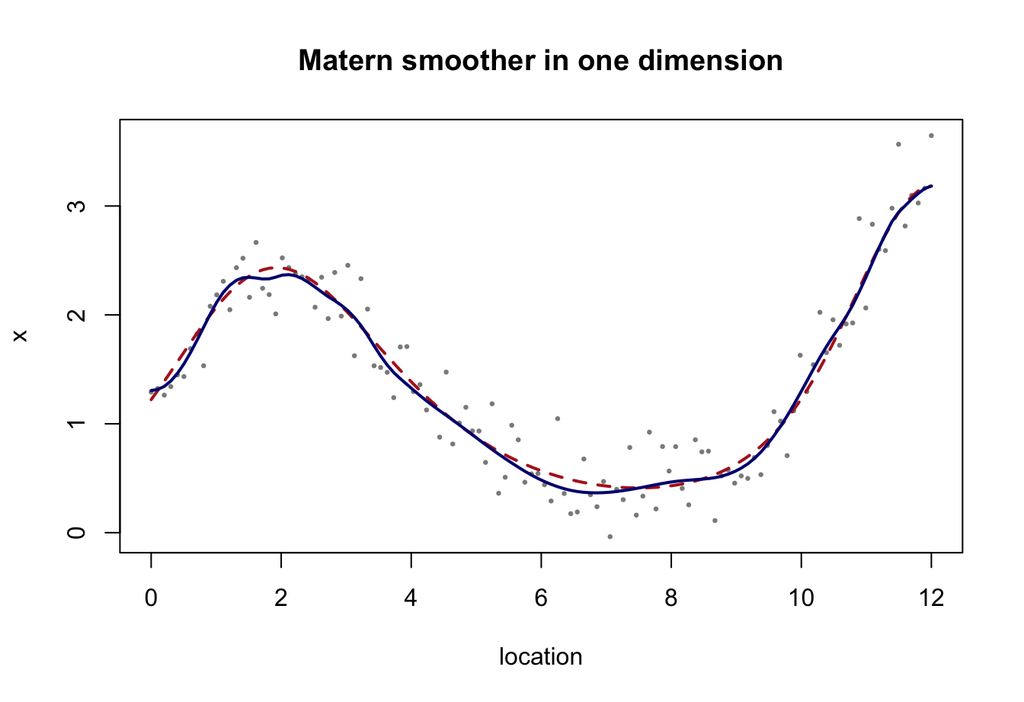

```r
plot(locations_1d, x_1d, pch = 16, cex = 0.45, col = "grey55",
     xlab = "location", ylab = "x",
     main = "Matern smoother in one dimension")
lines(locations_1d, truth_1d, col = "firebrick", lwd = 2, lty = 2)
lines(locations_1d, fit_1d$posterior$mean, col = "navy", lwd = 2)
```

# PC-Prior Fits

Supplying `pc.penalty` lets the Matern fitter select smoothing hyperparameters under a PC prior. With `link = "identity"` and `backend = "auto"`, this remains on the package exact Gaussian backend. Use explicit `backend = "inla"` when an independent INLA/SPDE comparison is needed.

```r
fit_fun_pc <- ebnm_Matern_generator(
  locations = locations_1d,
  link = "identity",
  pc.penalty = list(
    range = c(1.2, 0.5),
    sigma = c(0.6, 0.5)
  )
)

fit_pc <- fit_fun_pc(x_1d, s_1d)
pc_breakdown <- matern_objective_breakdown(fit_pc)

fit_pc$backend
```

```
#> [1] "exact"
```

```r
fit_pc$fitted_g
```

```
#> $theta
#> [1] 1.633616
#>
#> $sigma
#> [1] 0.8534111
#>
#> $beta
#> [1] 1.365165
#>
#> $beta_prec
#> NULL
#>
#> attr(,"class")
#> [1] "Matern"
```

```r
fit_pc$fitted_beta
```

```
#> [1] 1.365165
```

```r
fit_pc$log_likelihood
```

```
#> 'log Lik.' -20.85636 (df=NULL)
```

```r
fit_pc$log_likelihood_stepA_mlik_integration
```

[output not shown]

```r
pc_breakdown$objective_integrated_flat_plus_prior
```

[output not shown]

```r
pc_breakdown$recorded_minus_matched_exact
```

```
#> [1] 0
```

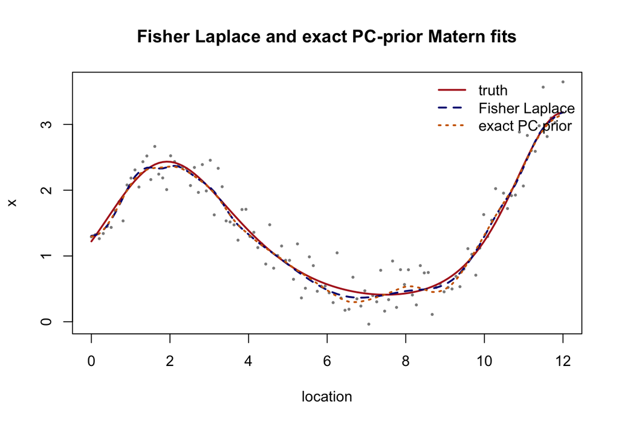

```r
plot(locations_1d, x_1d, pch = 16, cex = 0.45, col = "grey55",
     xlab = "location", ylab = "x",
     main = "Fisher Laplace and exact PC-prior Matern fits")
lines(locations_1d, truth_1d, col = "firebrick", lwd = 2, lty = 1)
lines(locations_1d, fit_1d$posterior$mean, col = "navy", lwd = 2, lty = 2)
lines(locations_1d, fit_pc$posterior$mean, col = "darkorange3", lwd = 2, lty = 3)
legend(
  "topright",
  legend = c("truth", "Fisher Laplace", "exact PC prior"),
  col = c("firebrick", "navy", "darkorange3"),
  lty = c(1, 2, 3),
  lwd = c(2, 2, 2),
  bty = "n"
)
```

# Fixed Hyperparameters and Fixed Intercept

When `fix_g = TRUE`, the Matern smoother fixes the smoothing hyperparameters from `g_init`. Supply `beta_fixed` separately when the intercept should also be fixed.

```r
set.seed(99)

fit_fixed <- fit_fun_1d(
  x_1d,
  s_1d,
  g_init = Matern(theta = log(1.2), sigma = 0.7),
  fix_g = TRUE,
  beta_fixed = 0.1
)

fit_fixed$fitted_g
```

```
#> $theta
#> [1] 0.1823216
#>
#> $sigma
#> [1] 0.7
#>
#> $beta
#> [1] 0.1
#>
#> $beta_prec
#> NULL
#>
#> attr(,"class")
#> [1] "Matern"
```

```r
fit_fixed$fitted_beta
```

```
#> [1] 0.1
```

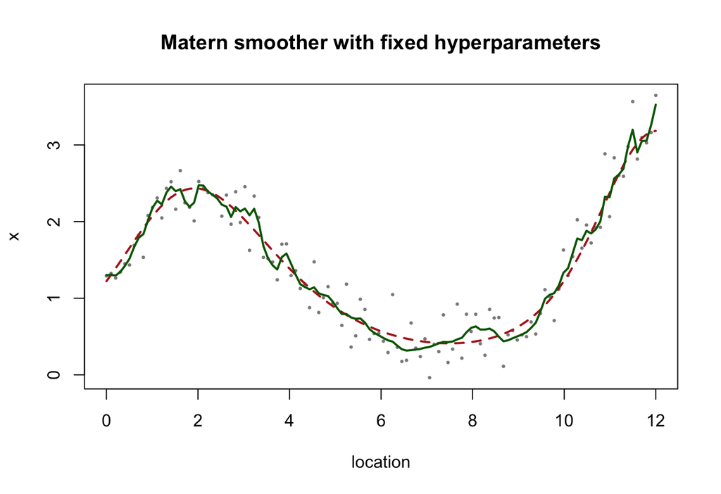

```r
plot(locations_1d, x_1d, pch = 16, cex = 0.45, col = "grey55",
     xlab = "location", ylab = "x",
     main = "Matern smoother with fixed hyperparameters")
lines(locations_1d, truth_1d, col = "firebrick", lwd = 2, lty = 2)
lines(locations_1d, fit_fixed$posterior$mean, col = "darkgreen", lwd = 2)
```

Range/sigma fixing is not supported by the INLA backend. If `pc.penalty` is supplied and you need fixed Matern hyperparameters, fit an unpenalized package backend for that fixed-parameter score instead of requesting an INLA PC-prior fit.

# Two-Dimensional Example

For a two-dimensional domain, pass an `n x 2` matrix of coordinates.

```r
set.seed(2026)

nx <- 14
ny <- 10
grid <- expand.grid(
  x = seq(0, 1, length.out = nx),
  y = seq(0, 1, length.out = ny)
)
locations_2d <- as.matrix(grid)

truth_2d <- with(
  grid,
  sin(2 * pi * x) * cos(2 * pi * y)
)
s_2d <- rep(0.15, nrow(locations_2d))
x_2d <- truth_2d + rnorm(nrow(locations_2d), sd = s_2d)

fit_fun_2d <- ebnm_Matern_generator(
  locations = locations_2d,
  max.edge = c(0.15, 0.3),
  link = "identity"
)

fit_2d <- fit_fun_2d(x_2d, s_2d)
```

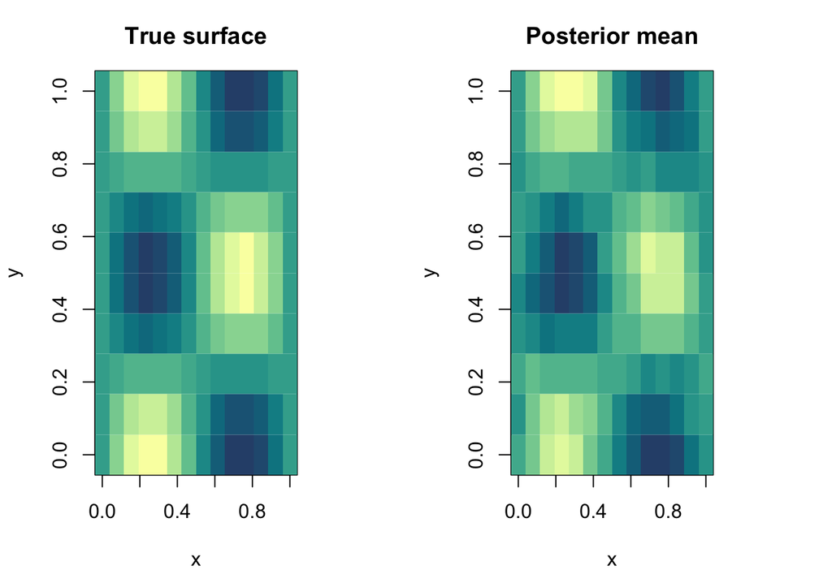

```r
op <- par(mfrow = c(1, 2), mar = c(4, 4, 3, 5))

z_truth <- matrix(truth_2d, nrow = nx, ncol = ny)
image(
  x = sort(unique(grid$x)),
  y = sort(unique(grid$y)),
  z = z_truth,
  main = "True surface",
  xlab = "x",
  ylab = "y",
  col = hcl.colors(20, "BluYl")
)

z_fit <- matrix(fit_2d$posterior$mean, nrow = nx, ncol = ny)
image(
  x = sort(unique(grid$x)),
  y = sort(unique(grid$y)),
  z = z_fit,
  main = "Posterior mean",
  xlab = "x",
  ylab = "y",
  col = hcl.colors(20, "BluYl")
)
```

```r
par(op)
```

# Useful Outputs

The Matern fitter returns backend-specific components in addition to the common `ebnm`-style fields:

```r
names(fit_1d)
```

```
#>  [1] "posterior"                     "fitted_g"
#>  [3] "fitted_beta"                   "beta_prec"
#>  [5] "beta_mode"                     "log_likelihood"
#>  [7] "log_likelihood_semantics"      "posterior_sampler"
#>  [9] "posterior_spatial_field"       "backend"
#> [11] "laplace_implementation"        "laplace_curvature"
#> [13] "link"                          "prior_family"
#> [15] "pc_penalty"                    "log_likelihood_pc_prior_theta"
#> [17] "laplace_diagnostics"           "matern_objective_context"
#> [19] "data"                          "mesh"
#> [21] "g_init"
```

```r
names(fit_pc)
```

```
#>  [1] "posterior"                     "fitted_g"
#>  [3] "fitted_beta"                   "beta_prec"
#>  [5] "beta_mode"                     "log_likelihood"
#>  [7] "log_likelihood_semantics"      "posterior_sampler"
#>  [9] "posterior_spatial_field"       "backend"
#> [11] "link"                          "prior_family"
#> [13] "pc_penalty"                    "log_likelihood_pc_prior_theta"
#> [15] "matern_objective_context"      "data"
#> [17] "mesh"                          "g_init"
```

```r
class(fit_1d$mesh)
```

```
#> [1] "fm_mesh_1d"   "inla.mesh.1d"
```

```r
class(fit_1d$inla_result)
```

```
#> [1] "NULL"
```

```r
class(fit_pc$inla_result)
```

```
#> [1] "NULL"
```

```r
head(fit_1d$posterior_spatial_field)
```

```
#>   ID      mean         sd 0.025quant  0.5quant 0.975quant      mode kld
#> 1  1 0.1752097 0.05937090 0.05884491 0.1752097  0.2915746 0.1752097   0
#> 2  2 0.1825030 0.05581092 0.07311564 0.1825030  0.2918904 0.1825030   0
#> 3  3 0.2041332 0.05073566 0.10469310 0.2041332  0.3035732 0.2041332   0
#> 4  4 0.2402230 0.04772569 0.14668234 0.2402230  0.3337636 0.2402230   0
#> 5  5 0.2889557 0.04702712 0.19678424 0.2889557  0.3811272 0.2889557   0
#> 6  6 0.3472612 0.04690952 0.25532026 0.3472612  0.4392022 0.3472612   0
#>           var
#> 1 0.003524904
#> 2 0.003114859
#> 3 0.002574107
#> 4 0.002277742
#> 5 0.002211550
#> 6 0.002200503
```

The mesh is still useful for diagnostics and visualization. The `posterior_spatial_field` component contains a latent-field summary for the mesh nodes.